# IDS Group Project

Formula E Race Result

Table 5 Tekkers Joel Barron, Jamie Burrell, Farhan Khan, Yara Kanaan,Muhammad Aiman, Hylda Azizi

2024-11-30

# Introduction and Question Setting

We chose to investigate Formula E race results because as many people follow Formula racing, we feel our results, if communicated effectively, are likely to interest the wider population. This data set allows us to identify trends in driver performance and consistency based on several factors including themselves, their team and the location of the race. This led us to our key question of *How do driver, team and location affect driver performance in Formula E races?*

# Data Cleaning

Our chosen data set was created from the scraping of 7 seasons’ worth of data from Wikipedia resulting in a data set with 19 variables and 1480 observations. The variables were a mix of characters and integers, reflecting a mix of categorical and numerical variables.

```
## Rows: 1,480
## Columns: 19
## $ season       <int> 2, 1, 5, 6, 6, 6, 4, 4, 4, 4, 5, 5, 1, 2, 2, 3, 3, 1, 2, …
## $ race_num     <int> 2, 4, 1, 2, 3, 8, 5, 9, 10, 11, 4, 10, 1, 6, 7, 4, 11, 6,…
## $ race_name    <chr> "2015 Putrajaya", "2015 Buenos Aires", "2018 Ad Diriyah",…
## $ race_date    <chr> "2015-11-07", "2015-01-10", "2018-12-15", "2019-11-23", "…
## $ driver       <chr> "Lucas di Grassi", "António Félix da Costa", "António Fél…
## $ car          <int> 11, 55, 28, 27, 28, 28, 66, 66, 1, 1, 11, 11, 11, 11, 11,…
## $ team         <chr> "ABT Schaeffler Audi Sport", "Amlin Aguri", "Andretti-BMW…
## $ team_group   <chr> "Audi", "Techeetah", "BMW-Andretti", "BMW-Andretti", "BMW…
## $ rank         <chr> "1", "1", "1", "1", "1", "1", "1", "1", "1", "1", "1", "1…
## $ rank_num     <int> 1, 1, 1, 1, 1, 1, 1, 1, 1, 1, 1, 1, 1, 1, 1, 1, 1, 1, 1, …
## $ grid         <chr> "6", "8", "1", "1", "2", "2", "5", "1", "5", "11", "2", "…
## $ laps         <chr> "33", "35", "33", "30", "40", "35", "47", "45", "39", "43…
## $ time_retired <chr> "50:17.449", "48:52.100", "46:29.377", "46:48.327", "46:1…
## $ pts_rank     <int> 25, 25, 25, 25, 25, 25, 25, 25, 25, 25, 25, 25, 25, 25, 2…
## $ pts_pole     <int> 0, 0, 3, 3, 0, 0, 0, 3, 0, 0, 0, 0, 0, 0, 0, 0, 3, 0, 3, …
## $ pts_bonus    <int> 0, 0, 0, 0, 0, 0, 0, 1, 0, 0, 0, 1, 0, 0, 0, 0, 0, 0, 0, …
## $ points       <int> 25, 25, 28, 28, 25, 25, 25, 29, 25, 25, 25, 26, 25, 25, 2…
## $ location     <chr> "Putrajaya", "Buenos Aires", "Diriyah", "Diriyah", "Santi…
## $ finished     <lgl> TRUE, TRUE, TRUE, TRUE, TRUE, TRUE, TRUE, TRUE, TRUE, TRU…
```

We decided to add the binary outcome of whether a driver finishes their race or is forced to retire, for example because of an accident or technical fault. We used the retired_time variable to create this new *finished* variable which is a logical TRUE/FALSE. The varied ways in which retired_time was recorded, in some cases as a time but in other cases based on laps, meant we had to account for various cases using the case_when function.

Particularly considering the possibility of accidents, we were keen to consider whether some tracks were particularly dangerous and so wanted to extract the location from the “race_name” variable which also included the year. We did this by using the str_detect function.

We then removed the variables which we were not going to use, leaving us with a much neater data set consisting of rank_num, a numerical outcome variable, *finished*, a binary outcome variable (which we converted to a factor for modelling), and *driver*, *location* and *team_group* as categorical predictor variables.

```
## Rows: 1,480
## Columns: 5
## $ driver     <chr> "Lucas di Grassi", "António Félix da Costa", "António Félix…
## $ team_group <chr> "Audi", "Techeetah", "BMW-Andretti", "BMW-Andretti", "BMW-A…
## $ location   <chr> "Putrajaya", "Buenos Aires", "Diriyah", "Diriyah", "Santiag…
## $ rank_num   <int> 1, 1, 1, 1, 1, 1, 1, 1, 1, 1, 1, 1, 1, 1, 1, 1, 1, 1, 1, 1,…
## $ finished   <lgl> TRUE, TRUE, TRUE, TRUE, TRUE, TRUE, TRUE, TRUE, TRUE, TRUE,…
```

# Summary Statistics

We started by exploring a summary of the statistical data for the top 10 formula E drivers. The metrics included are average rank, median rank, rank standard deviation and average points. Limiting this exploration to the first ten provided a more focused overview.

```
## # A tibble: 10 × 6
##    driver           avg_rank median_rank rank_sd avg_grid avg_points
##    <chr>               <dbl>       <dbl>   <dbl>    <dbl>      <dbl>
##  1 Sébastien Buemi      7.42         5      6.43     6.22      11.3
##  2 Lucas di Grassi      6.62         4      5.88     8.96      11.3
##  3 Jean-Éric Vergne     8.09         6      6.25     7.54       9.61
##  4 Franck Montagny     10.5         10.5   12.0     10.5        9
##  5 Pierre Gasly         5.5          5.5    2.12    11.5        9
##  6 Felix Rosenqvist     9.2          8      6.79     6.72       8.92
##  7 Sam Bird             8.39         7      6.37     8.55       8.86
##  8 Nyck de Vries       10.2          9      7.22     8.62       7.08
##  9 Nico Prost           8.44         8      4.87     8.8        6.78
## 10 Oliver Rowland       9.81         7      5.97    10.1        6.22
```

# Data Visualisations

After reviewing summary statistics, we used visualisations to help us understand how different variables affect the likelihood of a finish.

We started by drawing a simple scatter plot of rank_num (finishing position) against the 1-mean of each drivers *finished* variable: as *finished* is logical, its mean corresponds to the proportion of results that are true.

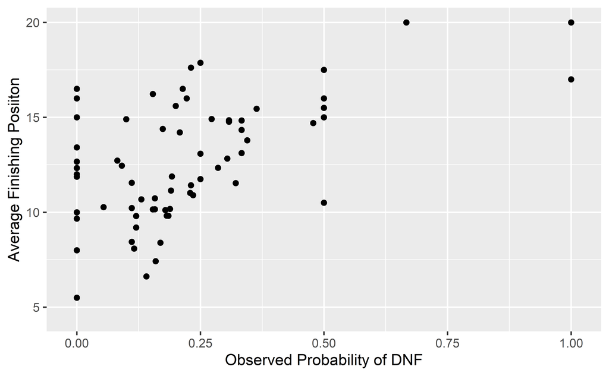

From this graph, we filtered out drivers with less than 10 races to remove outliers, then drew a simple linear regression line, which showed positive correlation between the two variables.

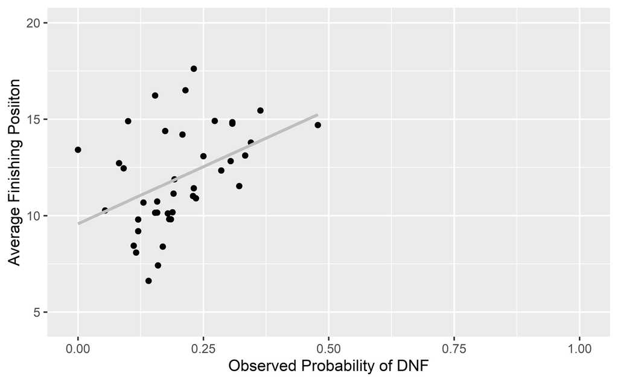

Upon analysing which points were furthest deviated from the line, we found a group of the highlighted “best drivers” lying below the line. This indicated that while how likely a driver is to finish a race being a good indicator of performance, it is not the only factor.

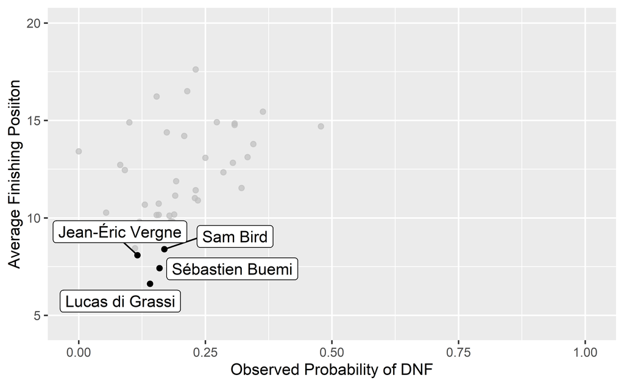

To further analyse how finishing was related to performance, we selected two sets of two drivers with similar average finishing positions, but different likelihoods of a DNF.

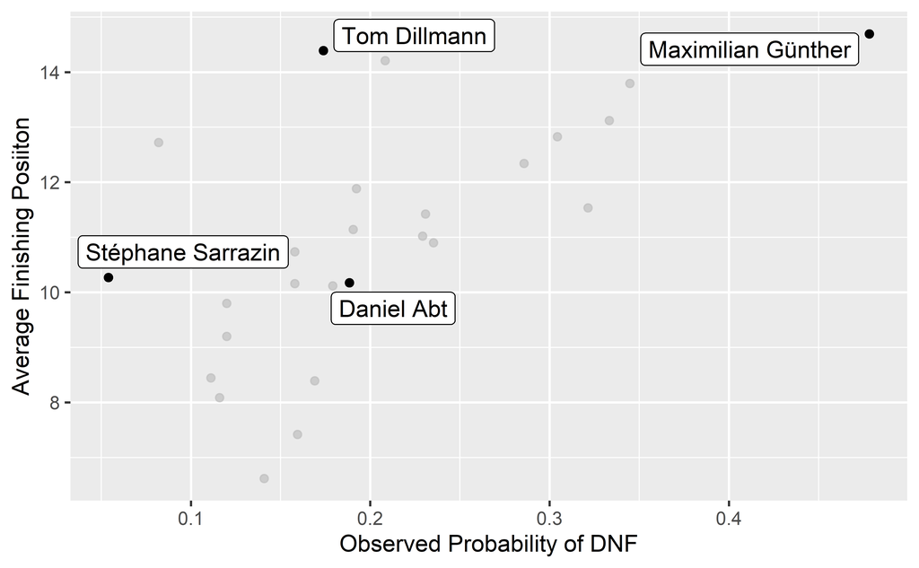

A new data set was created with the four chosen drivers, with an extra variable *order*: this was used to reorder the boxplots so exact comparisons were beside each other. This was further emphasised by manually setting the ones to compare as the same colour. We discovered that lower probability of recording a DNF corresponded to a lower IQR in both groups. We believe that this is a product of a driver’s “consistency”, thus giving another reason why the chance of a finish is a good indicator of driver performance, and better than just where a driver finishes.

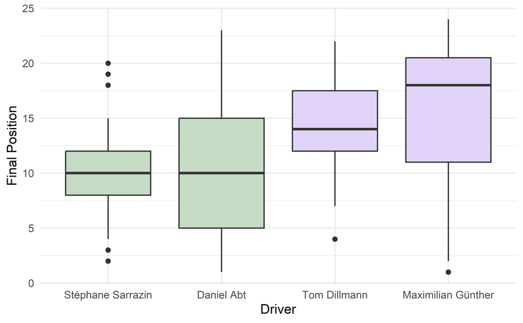

We also drew bar charts of the the probability of a DNF (as in the drivers’ graph) for each track location and team group. These plots showed enough signs of correlation to consider them for the model, and helped identify outliers. However, we did not deem the results sufficiently significant to present them here.

# Model Selection

The variable that we chose to predict is *finished*. We chose to predict *finished* as it is the binary outcome of whether a driver finishes their race or is forced to retire as a result of accident, technical fault or other reason. A driver who consistently finishes races demonstrates skill in managing the car, energy, and strategy over the course of the event. Consistently finishing high-pressure races can also correlate with the ability to adapt to changing conditions such as weather, competitors and track conditions which indicate the performance of the driver. The predictors we chose are based on the visualisations above, and are the driver, the location of the race and the team.

As we are predicting a logical outcome, we used a generalised linear model (GLM) which is logistic regression. Logistic regression is a GLM used to model a binary categorical outcome using numerical and categorical predictors.

```r
raceresults_mod <- logistic_reg() %>%
  set_engine("glm")
```

# Model Implementation

```r
set.seed(28)
raceresults_split <- initial_split(raceresults_factored)
raceresults_train <- training(raceresults_split)
raceresults_test <- testing(raceresults_split)

raceresults_rec <- recipe(finished_fct ~ driver + team_group + location, data = raceresults_train) %>%
  step_dummy(all_nominal(), -all_outcomes())
```

We used this recipe and our model to create a workflow which we then applied to our training data.

```r
raceresults_wflow <- workflow() %>%
  add_recipe(raceresults_rec) %>%
  add_model(raceresults_mod)
```

The result of this were estimated model coefficients showing how much each predictor (race location, driver and team) impacted the outcome of the race.

```r
raceresults_fit <- raceresults_wflow %>%
  fit(data = raceresults_train)
tidy(raceresults_fit)
```

```
## # A tibble: 55 × 5
##    term                          estimate std.error statistic p.value
##    <chr>                            <dbl>     <dbl>     <dbl>   <dbl>
##  1 (Intercept)                     0.198      1.69      0.117   0.907
##  2 driver_Alexander.Sims           0.424      1.01      0.418   0.676
##  3 driver_André.Lotterer          -0.766      1.12     -0.687   0.492
##  4 driver_António.Félix.da.Costa   0.0904     0.887     0.102   0.919
##  5 driver_Bruno.Senna             -1.62       1.08     -1.51    0.132
##  6 driver_Daniel.Abt              -0.490      1.59     -0.309   0.758
##  7 driver_Edoardo.Mortara         -0.468      1.14     -0.412   0.680
##  8 driver_Felipe.Massa            -1.06       1.23     -0.866   0.387
##  9 driver_Felix.Rosenqvist        -1.28       0.954    -1.34    0.180
## 10 driver_Jean.Éric.Vergne        -0.996      0.896    -1.11    0.266
## # ℹ 45 more rows
```

Positive estimates indicate that the predictor increases the probability of the driver not finishing the race ( *finished* = FALSE) compared to the baseline, while negative estimates decrease the probability of a DNF. Based on the model, the driver with the highest positive coefficient is Maximillian Gunther with an estimate of 1.6830. Thus, it means that this driver is significantly more likely not to finish his race. For the team group, BMW Andretti has an estimate of -0.7857 which is the highest negative coefficient among all the team groups. This shows that BMW Andretti drivers are much more likely to finish their races than drivers from the baseline team (Audi).

We then used the test data to evaluate how the model does making predictions based on unseen variables in the testing data, to guard against overfitting.

```r
raceresults_pred <- predict(raceresults_fit, raceresults_test, type = "prob") %>%
  bind_cols(raceresults_test)
raceresults_pred
```

```
## # A tibble: 280 × 8
##    .pred_TRUE .pred_FALSE driver           team_group location rank_num finished
##         <dbl>       <dbl> <chr>            <chr>      <chr>       <int> <lgl>
##  1      0.856      0.144  Lucas di Grassi  Audi       Putraja…        1 TRUE
##  2      0.659      0.341  Maximilian Günt… BMW-Andre… Berlin          1 TRUE
##  3      0.819      0.181  Daniel Abt       Audi       Mexico …        1 TRUE
##  4      0.942      0.0578 Lucas di Grassi  Audi       Berlin          1 TRUE
##  5      0.738      0.262  Lucas di Grassi  Audi       Beijing         1 TRUE
##  6      0.940      0.0604 Lucas di Grassi  Audi       Long Be…        1 TRUE
##  7      0.875      0.125  Felix Rosenqvist Mahindra   Hong Ko…        1 TRUE
##  8      0.893      0.107  Stoffel Vandoor… Mercedes   Berlin          1 TRUE
##  9      0.715      0.285  Sébastien Buemi  Nissan-Re… Beijing         1 TRUE
## 10      0.841      0.159  Jean-Éric Vergne Techeetah  Punta d…        1 TRUE
## # ℹ 270 more rows
## # ℹ 1 more variable: finished_fct <fct>
```

# Model Evaluation

To evaluate our logistic regression model, we plotted an ROC curve to evaluate the percentage of variability in *finished* that is predicted by our model with *driver*, *team_group*, and *location*. We obtained an AUC value of 0.563 for this model, which suggests that our model does slightly better than random (0.5), suggesting that while weak, the combination of driver, team and location do have an impact on whether they finish the race.

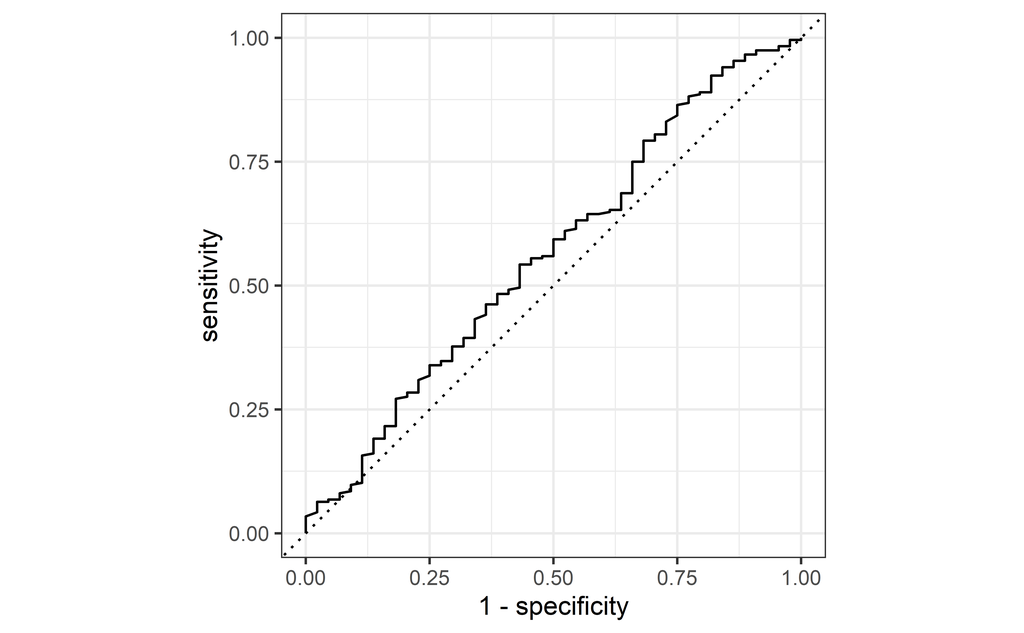

All combinations of 1 and 2 variables yield lower AUC results, suggesting this is not an overfitting, however the *location* variable on its own yields almost just as good a model as the three of them together (0.558).

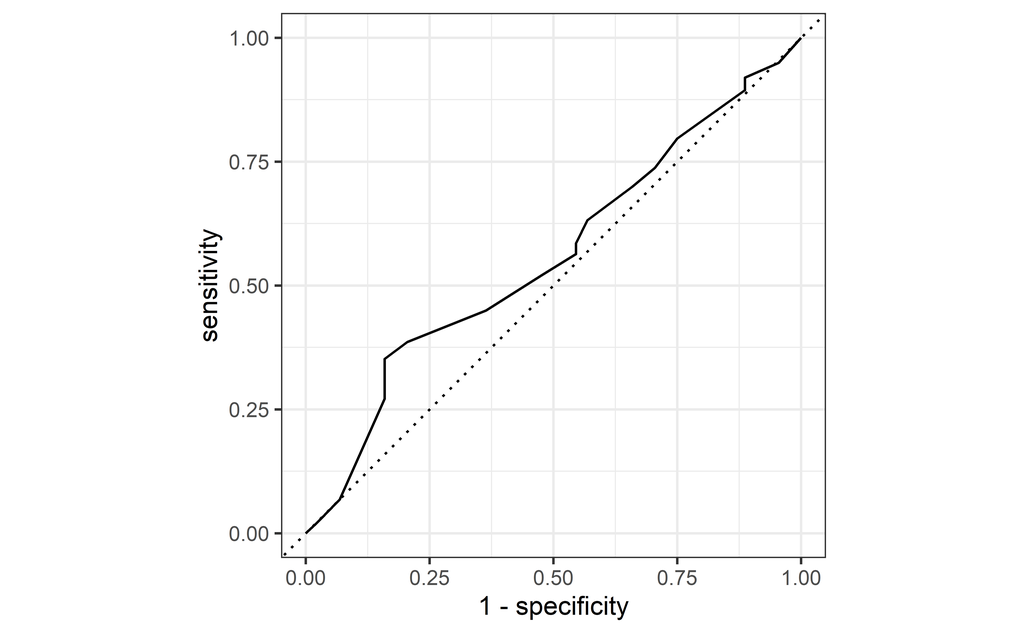

Ultimately however, these AUC values close to the random estimate value of 0.5 show that we cannot say for sure that driver, team and/or location are strong predictors of whether a driver finishes, and so of driver performance.

# Summary

In conclusion, our investigation of driver performance in Formula E races suggests that the driver, team and location of a race do have a marginal impact on whether a driver finishes the race, and so on driver performance. However, the inconclusive nature of these results suggests that further study is required to understand whether other factors we have not considered, for example the weather on race days, might be more impactful.

# Citation

M. Landry. (2021). ‘Formula E Championship’. Available at https://www.kaggle.com/datasets/mlandry/formula-e-championship/data. Accessed 18/10/2024.